# Analysis of the data published by Sun, M. et.al (2013)

Aliaksandr Damenikan

July-August 2018

## Goal

The data published by Sun, M. et.al contains results of a large scale experiment aiming at identifying (i) total RNA abundance, (ii) synthesis rates (SR) and (iii) degradation rates changes of 4305 genes of S.cerevisiae in 47 strains bearing mutations in genes involved in RNA processing and degradation. The goal of this analysis was to dissect the data and identify behaviour of the genes we are currently interested in as well as attempt to find new patterns in the whole dataset.

The data was published in:

```
Sun, M., Schwalb, B., Pirkl, N., Maier, K. C., Schenk, A., Failmezger, H., … Cramer, P. (2013). Global analysis of Eukaryotic mRNA degradation reveals Xrn1-dependent buffering of transcript levels. Molecular Cell, 52(1), 52–62. https://doi.org/10.1016/j.molcel.2013.09.010
```

## Total mRNA level, DR and SR data for genes of our interest

Building heatmap for the desired gene set from SR, DR and total RNA level data

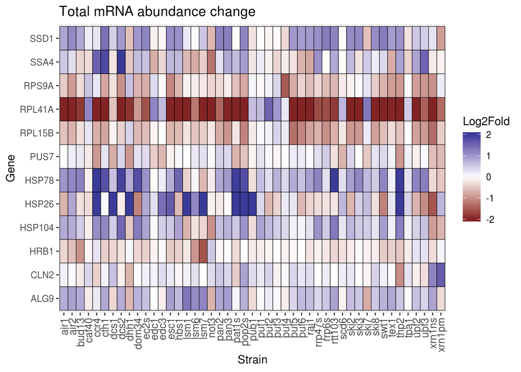

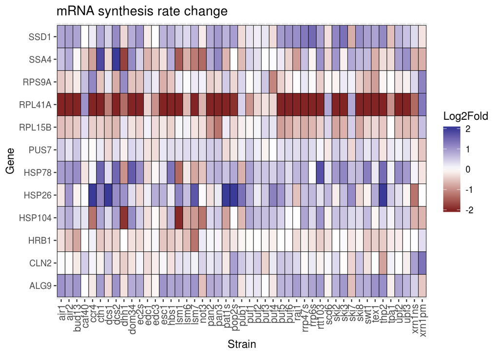

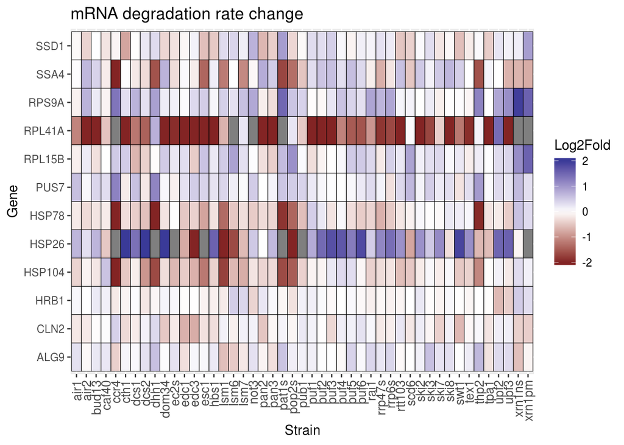

## Cluster analysis of DR, SR and Total mRNA data for ribosomal and heat-shock proteins

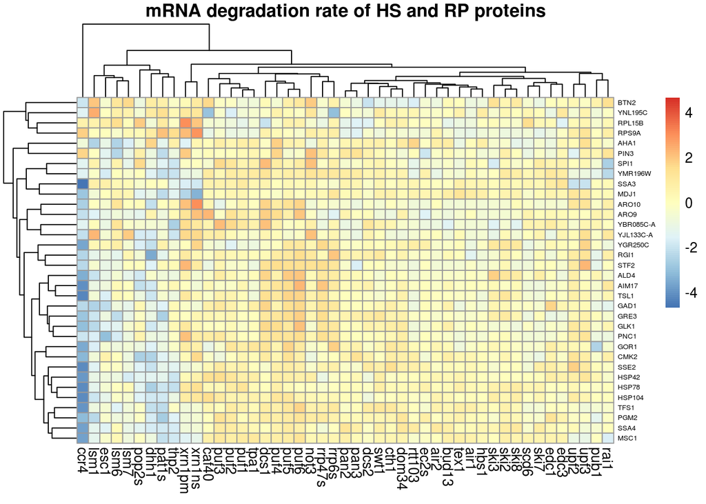

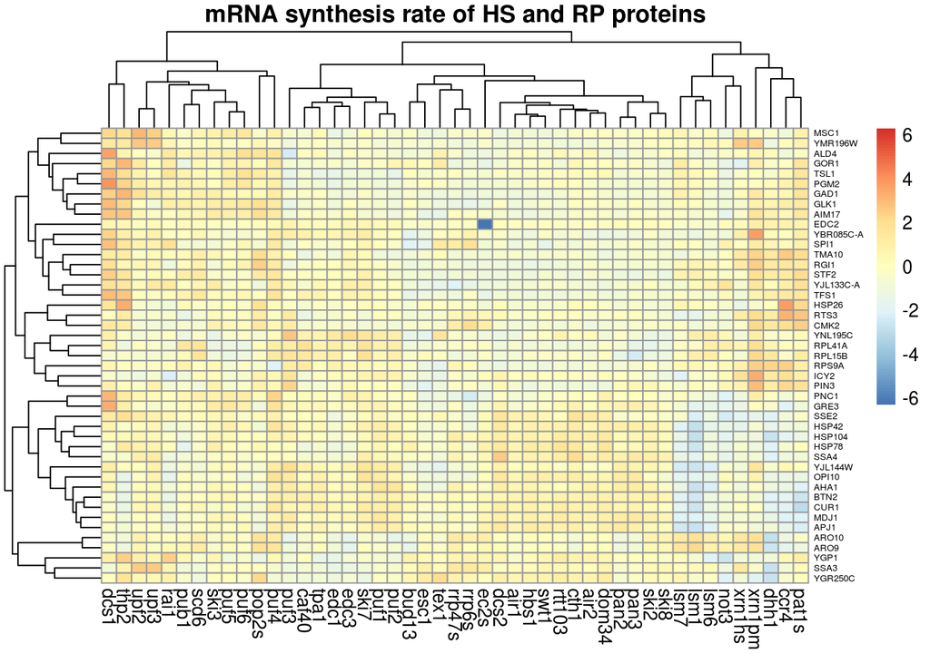

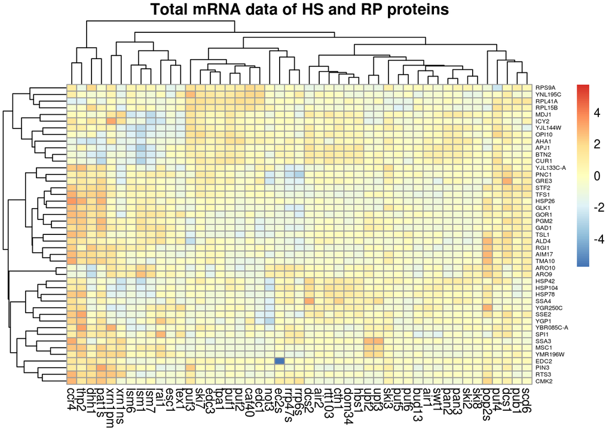

Unfortunately I cannot see many of the ribosomal proteins in the dataset (may be different names?). From the this heatmaps (especially SR and total mRNA data) I would conclude, that heatshock proteins fall in several groups. DR data does not show the same kind of patterns, just as in the whole dataset (see below).

## SR data clustering and reordering DR and Total mRNA data

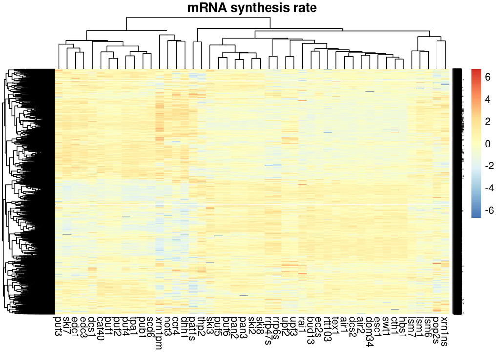

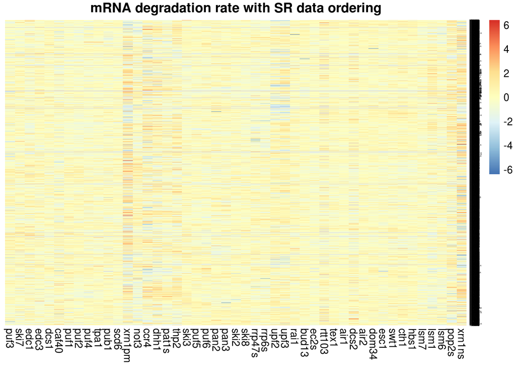

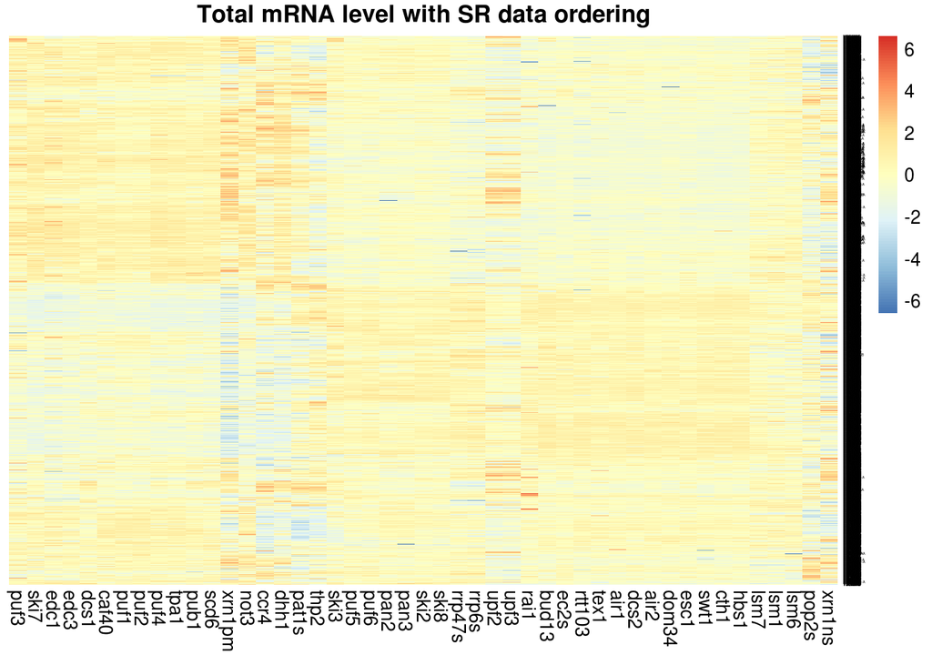

Interestingly the pattern seen in SR data preserves in Total mRNA data but not DR data. Also please notice that the SR effects of the xrn1_insertion (xrn1ns) mutant is very similar to pop2s mutant. Considering role of the xrn1 in “buffering” this might be interesting.

## DR data clustering and reordering SR and Total mRNA data

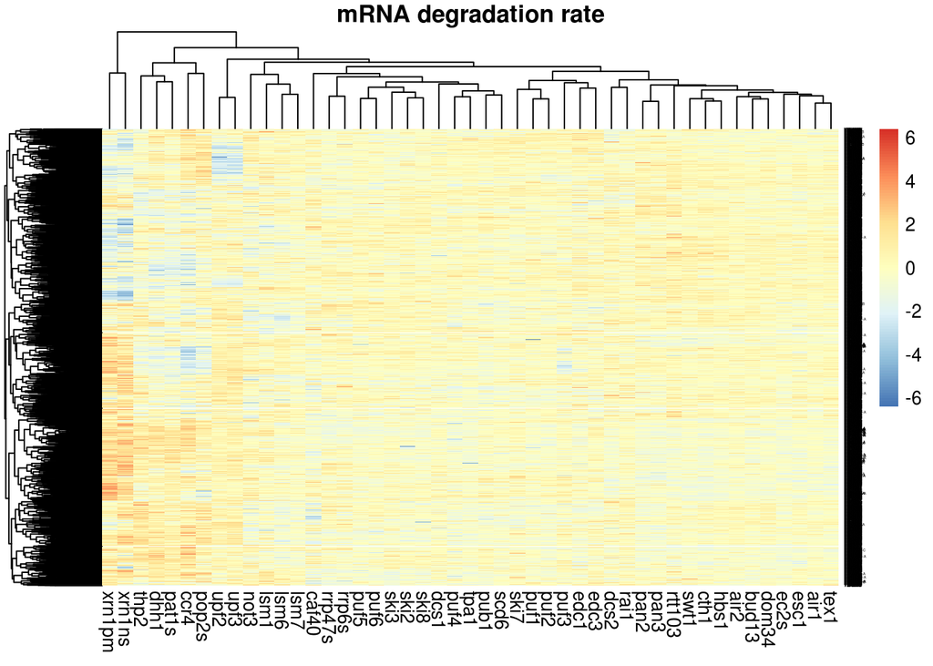

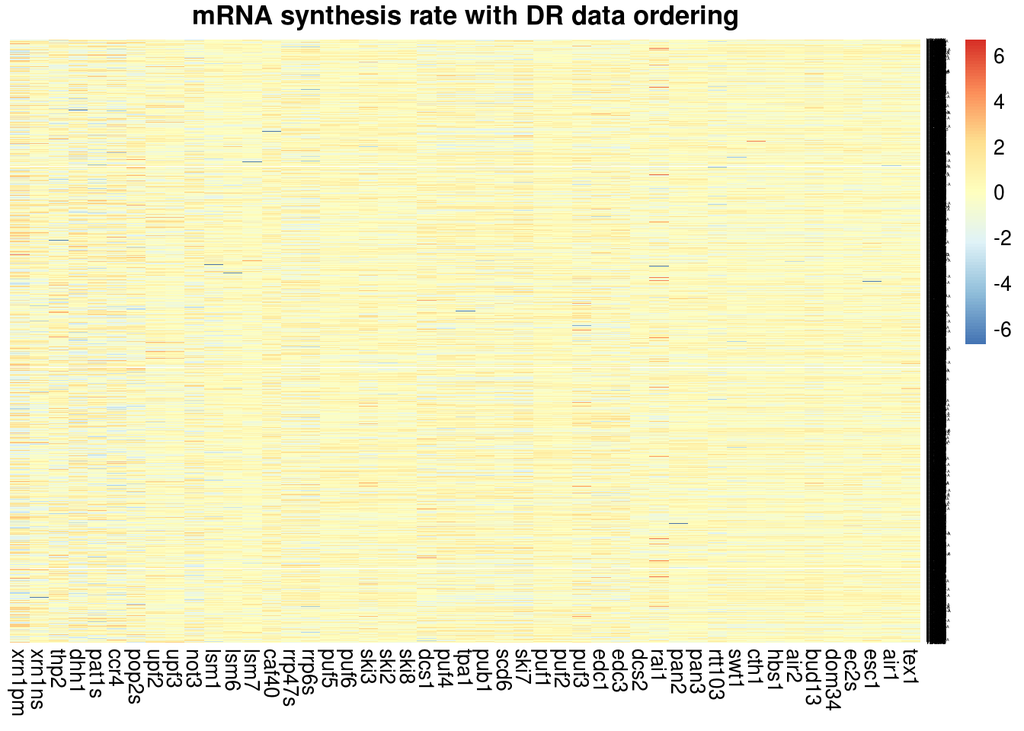

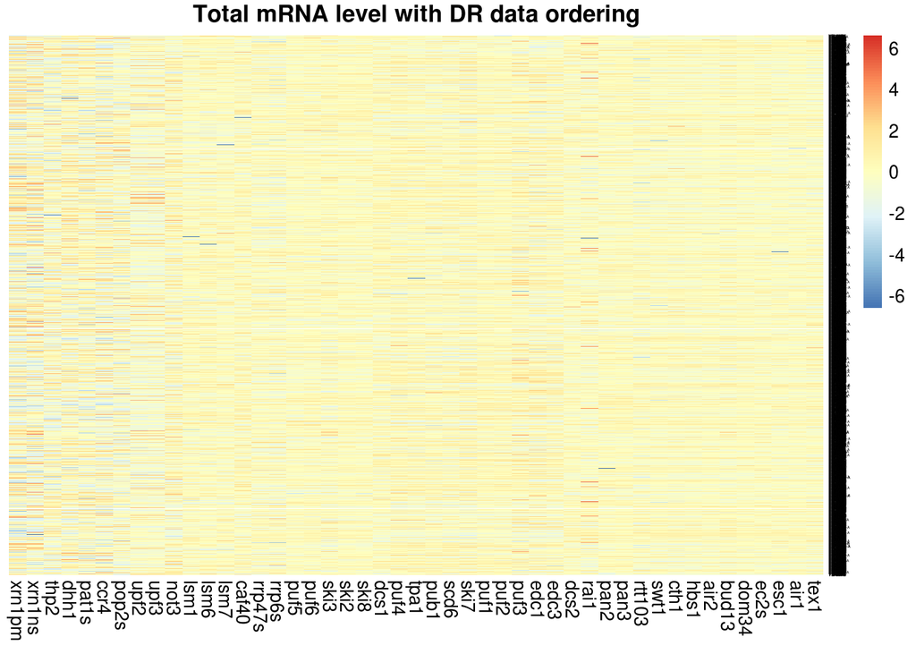

I cannot see any particular pattern in DR data except that xrn1, ccr4, dhh1, pop2 have very pronounced effects comparing to other mutants. SR and Total mRNA data does not show similar picture, although above-mentioned mutants still have larger effects in Total mRNA data.

## Total mRNA data clustering and reordering SR and DR mRNA data

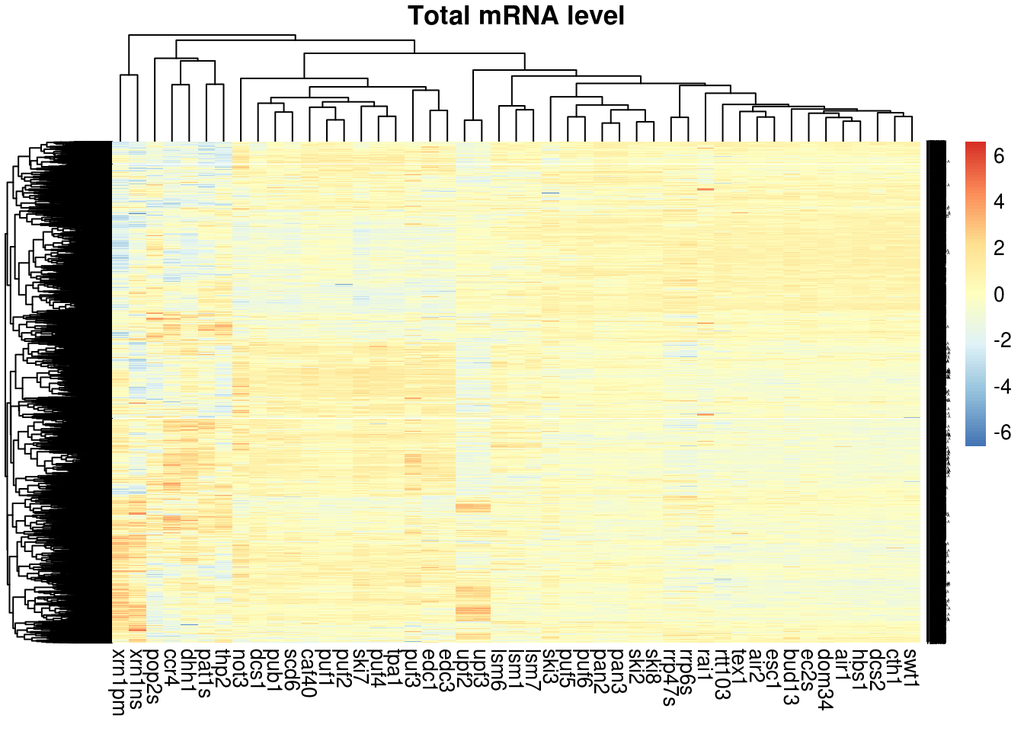

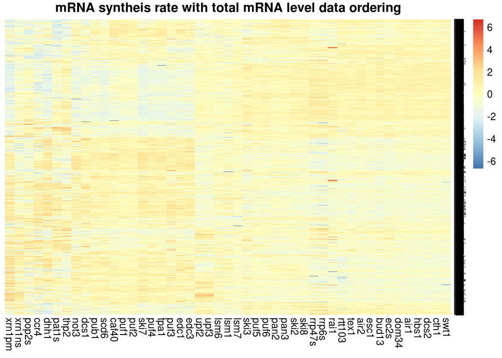

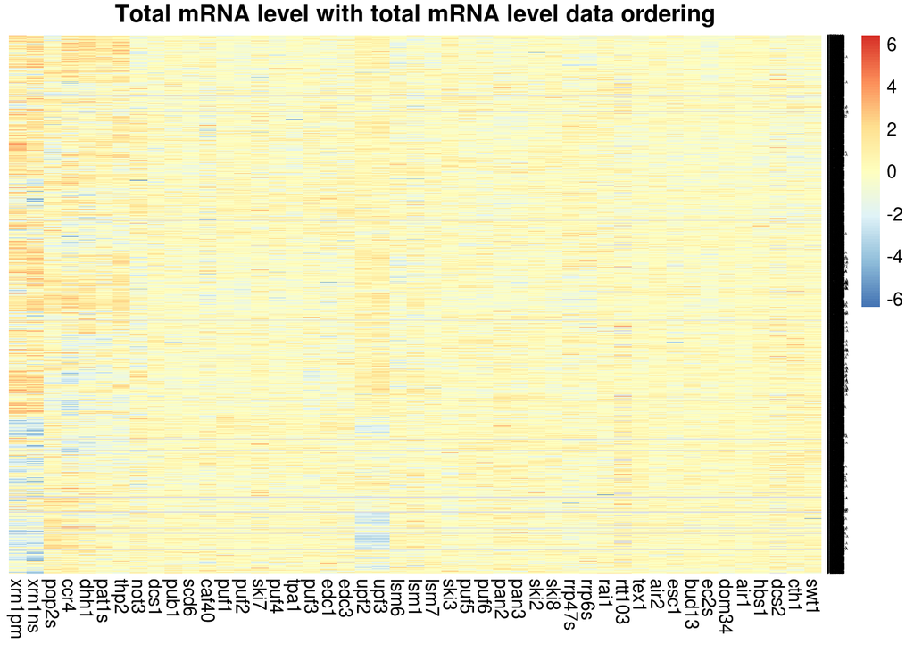

Again same pattern seen in Total mRNA data and SR data, but not DR data. Does it mean that the effects on total mRNA levels is dictated more by Synthesis rate change in all these mutants rather than DR?..

## Gene Ontology (GO) enrichment analysis

The analysis was carried out using 4 clusters readily visiable drom the SR data clustering above. The numeration of clusters from the top of the SR heatmap: 3, 2, 1, 4.

```
##         GO.ID                            Term Annotated Significant
## 1  GO:0016020                        membrane      1557         686
## 2  GO:0012505             endomembrane system       906         440
## 3  GO:0071944                  cell periphery       566         304
## 4  GO:0005886                 plasma membrane       367         213
## 5  GO:0031224 intrinsic component of membrane      1032         479
## 6  GO:0044425                   membrane part      1260         560
## 7  GO:0016021  integral component of membrane       998         463
## 8  GO:0005783           endoplasmic reticulum       533         271
## 9  GO:0031984        organelle subcompartment       449         234
## 10 GO:0005773                         vacuole       379         200
##    Expected  pValue
## 1    519.12 5.3e-29
## 2    302.07 5.6e-27
## 3    188.71 6.0e-27
## 4    122.36 2.7e-24
## 5    344.08 6.3e-24
## 6    420.10 6.1e-23
## 7    332.74 6.9e-23
## 8    177.71 3.4e-19
## 9    149.70 3.2e-18
## 10   126.36 2.5e-16
```

```
##         GO.ID                                  Term Annotated Significant
## 1  GO:0044429                    mitochondrial part       519         364
## 2  GO:0098798         mitochondrial protein complex       186         156
## 3  GO:0000313                   organellar ribosome        87          84
## 4  GO:0005761                mitochondrial ribosome        87          84
## 5  GO:0005740                mitochondrial envelope       355         242
## 6  GO:0005743          mitochondrial inner membrane       215         161
## 7  GO:0031966                mitochondrial membrane       329         225
## 8  GO:0000315    organellar large ribosomal subunit        49          49
## 9  GO:0005762 mitochondrial large ribosomal subunit        49          49
## 10 GO:0044391                     ribosomal subunit       100          86
##    Expected  pValue
## 1    233.45 < 1e-30
## 2     83.67 4.3e-29
## 3     39.13 5.0e-26
## 4     39.13 5.0e-26
## 5    159.68 3.3e-20
## 6     96.71 6.3e-20
## 7    147.99 4.5e-19
## 8     22.04 7.1e-18
## 9     22.04 7.1e-18
## 10    44.98 7.7e-18
```

```
##         GO.ID                                        Term Annotated
## 1  GO:0005634                                     nucleus      1877
## 2  GO:0005730                                   nucleolus       243
## 3  GO:0031981                               nuclear lumen       748
## 4  GO:0044428                                nuclear part       990
## 5  GO:0030684                                 preribosome       127
## 6  GO:0043228              non-membrane-bounded organelle      1075
## 7  GO:0043232 intracellular non-membrane-bounded organ...      1075
## 8  GO:0031974                     membrane-enclosed lumen      1018
## 9  GO:0043233                             organelle lumen      1018
## 10 GO:0070013               intracellular organelle lumen      1018
##    Significant Expected  pValue
## 1          394   272.13 2.2e-26
## 2           96    35.23 3.3e-23
## 3          190   108.45 1.5e-18
## 4          226   143.53 3.2e-16
## 5           55    18.41 1.3e-15
## 6          220   155.86 3.3e-10
## 7          220   155.86 3.3e-10
## 8          206   147.59 5.2e-09
## 9          206   147.59 5.2e-09
## 10         206   147.59 5.2e-09
```

```
##         GO.ID                 Term Annotated Significant Expected pValue
## 1  GO:0005576 extracellular region        55          11     3.95 0.0015
## 2  GO:0071944       cell periphery       566          57    40.64 0.0038
## 3  GO:0005773              vacuole       379          40    27.21 0.0072
## 4  GO:0038201          TOR complex        12           4     0.86 0.0081
## 5  GO:0005811        lipid droplet        43           8     3.09 0.0102
## 6  GO:0005777           peroxisome        61          10     4.38 0.0106
## 7  GO:0042579            microbody        61          10     4.38 0.0106
## 8  GO:0044438       microbody part        35           7     2.51 0.0107
## 9  GO:0044439     peroxisomal part        35           7     2.51 0.0107
## 10 GO:0000322      storage vacuole       324          33    23.26 0.0231
```